# 20261-SETUP summary

# Basics

- AI-Hub.html 참고

## Hardware

- Hardware

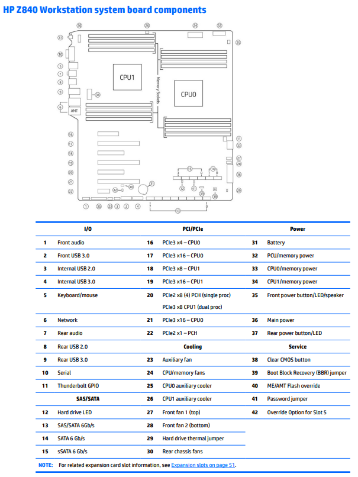

- HP840-mb.png

### Mainboard

### CPU

#### PC CPU

#### Server CPU

### RAM

#### PC

#### ECC

### Storage

#### HDD

#### SSD

#### Nvme

### PCIe

#### GPU

### NIC

## OS

- OS

[figure not shown]

- Simple History of OS

### Unix/Linux

### MS

### Mac

### etc

## Network

- Network

### IP

- “Public IP는 1개만 있고 여러 대의 컴퓨터로 내부망을 구성하고 인터넷을 써야 하고, 내부망 구성 컴퓨터들은 Static IP를 가져야 하는 상황” => 1개의 Public (Static, Dynamic 상관없음) IP + 여러 개의 Private Static IP
- IP 주소 구분
  - Static vs Dynamic: IP 주소 할당 방식의 차이 (고정 vs 자동).
  - Public vs Private: IP 주소 사용 범위의 차이 (외부망 vs 내부망).

| 구분 | 할당 방식(고정/자동) | 사용 범위 (내부/외부) | 특징 |
| --- | --- | --- | --- |
| Static IP | 고정 (관리자가 직접 설정) | 내부 또는 외부 모두 가능 | 항상 동일한 IP, 서버·프린터 등 고정 필요 장치에 사용 |
| Dynamic IP | 자동 (DHCP 서버 할당) | 내부 또는 외부 모두 가능 | 시간이 지나면 변경 가능, 일반 사용자 PC·모바일 |
| Public IP | ISP가 제공 (고정/자동 모두 가능) | 인터넷 전체에서 유효 | 외부에서 직접 접근 가능, 웹 서버·클라우드 서비스 |
| Private IP | 고정 또는 자동 모두 가능 | 내부 네트워크에서만 유효 | 외부 직접 접근 불가, NAT/포트포워딩 필요, 가정·기업 내부망 10.0.0.0 ~ 10.255.255.255 172.16.0.0 ~ 172.31.255.255 192.168.0.0 ~ 192.168.255.255 |

- IP 주소 구분 표

|  | Public IP (외부망) | Private IP (내부망) |
| --- | --- | --- |
| Static IP | ISP 또는 관리자가 고정 설정한 공인 IP 예: 웹 서버, 클라우드 서비스 | 관리자가 내부망에서 고정 설정한 사설 IP 예: 사내 서버, NAS, 프린터 |
| Dynamic IP | ISP가 DHCP로 자동 할당하는 공인 IP 예: 가정용 인터넷, 모바일 데이터 | 내부 DHCP 서버가 자동 할당하는 사설 IP 예: 가정/기업 내부 PC, IoT 기기 |

- 주요 환경별 내부망 IP 기본값(사설망 대역)

| 환경 | 기본 내부망 IP 대역 | 특징 |
| --- | --- | --- |
| WSL1 | 별도 내부망 없음 | Windows와 동일 네트워크 스택 공유, IP 따로 할당되지 않음 |
| WSL2 | 동적 할당 (`172.16.x.x ~ 172.31.x.x`) | Hyper-V 기반 NAT 네트워크, 실행 시마다 IP가 바뀜. W11(host)가 게이트웨이 역할 |
| Docker (Linux) | `172.17.0.0/16` | 브리지(docker0=172.17.0.1,subnet=172.17.0.0/16)에서 컨테이너(172.17.0.2~)에 할당 |
| k8s (CNI) | Pod: `10.244.0.0/16` (Flannel) Service: `10.96.0.0/12` | CNI 플러그인에 따라 다르며, 클러스터 생성 시 설정 가능 |
| vbox (NAT 모드) | VM 기본 IP: `10.0.2.15` 게이트웨이: `10.0.2.2` | NAT 모드에서 항상 동일한 기본값, 포트포워딩으로 외부 접근 가능 |

### Ports

- 포트(Port): 네트워크 포트. 하나의 IP 주소 내에서 여러 개의 서비스(프로그램/프로세스)를 구분하기 위한 논리적 번호
  - IP 주소가 건물 주소라면, 포트 번호는 그 건물 안의 특정 방 번호
  - 16비트 숫자(0~65535). 통신시 연결할 앱을 식별
  - 클라이언트는 임시 포트(Ephemeral) 사용, 서버는 서비스용 포트(Well-Known/Registered) 사용
  - 예: 웹 브라우저(클라이언트)는 임시 포트 `55000`을 열고, 서버의 `443(HTTPS)` 포트로 접속
- 포트 구분
- 대표적인 포트 번호

| 범위 | 포트 | 서비스 | 설명 |
| --- | --- | --- | --- |
| Well-Known Ports (0–1023) | 22 | SSH(Secure SH) | 보안 원격 접속 |
| 표준 서비스용 | 25 | SMTP | 메일 전송 |
|  | 53 | DNS | 도메인 이름 시스템 |
|  | 80 | HTTP | 웹 서비스 기본 포트 |
|  | 443 | HTTPS | 보안 웹 서비스 |
| Registered Ports (1024–49151) | 1433 | MS SQL Server | 데이터베이스 서버 |
| 특정 앱용 | 3306 | MySQL | 데이터베이스 서버 |
|  | 5432 | PostgreSQL | 데이터베이스 서버 |
|  | 27017 | MongoDB | NoSQL 데이터베이스 기본 포트 |
|  | 3000 | Grafana, Node.js 앱 | 모니터링/웹 앱 |
|  | 3389 | RDP (Remote Desktop) | 원격 데스크톱 |
|  | 7860 | Gradio | 머신러닝 데모용 웹 인터페이스 |
|  | 8501 | Streamlit | Python 웹 앱 프레임워크 |
|  | 8787 | RStudio Server | 웹 기반 R 개발 환경 |
|  | 8888 | Jupyter Notebook | 데이터 과학용 웹 인터페이스 |
|  | 9090 | Prometheus, Cockpit | 모니터링/서버 관리 |
|  | 8080 | Tomcat/Proxy | 대체 HTTP 포트 |
|  | 4822 | Apache Guacamole | 원격 데스크톱 게이트웨이 |
| Dynamic/Ephemeral Ports (49152–65535) |  | 웹 브라우저, API 호출 | 클라이언트가 서버와 연결할 때 열리는 임시 포트 세션 종료 시 반환됨 |

### SSH 보안 강화 예시

| 내용 | 명령/설정 예시 | 효과 |
| --- | --- | --- |
| 1. 기본 포트 변경 | /etc/ssh/sshd_config에 `Port 2222` | 자동화된 스캐닝 공격 회피, 로그 노이즈 감소 |
| 2. 루트 계정 직접 로그인 금지 | /etc/ssh/sshd_config에 `PermitRootLogin no` | 루트 계정 공격 차단, 일반 계정 → sudo 사용 |
| 3. 비밀번호 로그인 비활성화 | /etc/ssh/sshd_config에 `PasswordAuthentication no` `PubkeyAuthentication yes` | 무차별 대입 공격 방지, 키 기반 인증만 허용 |
| 4. 공개키 인증 설정 | `ssh-keygen -t ed25519` 후 공개키를 `~/.ssh/authorized_keys`에 등록 | 강력한 인증, 비밀번호 노출 위험 제거 |
| 5. Fail2ban 설치 및 설정 | `sudo apt install fail2ban` | 로그인 실패 횟수 초과 시 IP 자동 차단 |
| 6. 방화벽 설정 | `sudo ufw allow from 203.0.113.5 to any port 2222` | 특정 IP만 접근 허용, 불필요한 외부 접근 차단 |
| 7. VPN 또는 Jump Host 사용 | VPN/Bastion Host 통해서만 SSH 허용 | 외부 직접 접근 불가, 내부망만 허용 |
| 8. 최신 보안 업데이트 적용 | `sudo apt update && sudo apt upgrade` | 알려진 취약점 방지, 최신 보안 패치 유지 |

### 네트워크 장비

- 네트워크 장비: OSI 7계층 중 특정 계층에서 동작하며, 데이터 전송·연결·제어 기능을 담당하는 HW 또는 SW
- 주요 장비

| 장비 | OSI | 주요 기능 |
| --- | --- | --- |
| 리피터 (Repeater) | L1 물리 계층 | 단순 신호 증폭·재생산, 전송 거리 확장 |
| 허브 (Hub) | L1 물리 계층 | 단순 연결 장치, 입력 신호를 모든 포트로 브로드캐스트. 거의 안씀 |
| 브릿지 (Bridge) | L2 데이터링크 계층 | 네트워크 세그먼트 연결, MAC 주소 기반 필터링·전달. NAT 없이 단순 스위치 역할 |
| 스위치 (Switch, L2) | L2 데이터링크 계층 | MAC 주소 기반 패킷 전달, 충돌 도메인 분리. 공유기의 LAN 포트 |
| 스위치 (L3) | L3 네트워크 계층 | IP 주소 기반 라우팅 기능 포함, VLAN 간 통신 지원. NAT기능 없음 |
| 스위치 (L4) | L4 전송 계층 | TCP/UDP 포트 기반 트래픽 제어, QoS·로드밸런싱. 공유기에 기능 없음 |
| 라우터 (Router, Gateway) | L3 네트워크 계층 | 서로 다른 네트워크 연결(WAN과 LAN 연결결), IP 주소 기반 경로 선택·라우팅 |
| 공유기 (Home Gateway) | L3+L2+L1 통합 | 라우터+스위치+무선AP+NAT+DHCP+방화벽, 가정/소규모 네트워크 중심 장치 |

- 라우팅(경로 탐색) vs NAT(주소 변환)

### 공유기

- 하나의 인터넷 회선을 여러 기기에 나누어 제공. 가정용, 소규모 네트워크 통합 장비
- 공유기 = 라우터(WAN<=>LAN) + (L2)스위치(LAN 포트 4개) + 무선AP 기능 + DHCP 서버 + NAT
- 공유기 사용 목적
  - 인터넷 사용: NAT로 처리. 인터넷 사용하려면 공인 IP가 필요한데 공인 IP 1개지만 사설 IP로 여러대를 연결하고 인터넷을 사용할 수 있도록 주소를 변환
  - 사설 IP 할당 자동화: DHCP 기능
  - 허브는 이제 사용 안함
  - 브릿지(MAC기반 필터링)도 이제 거의 없음. 공유기의 무선 AP기능에 해당

| 기능 | OSI | 설명 |
| --- | --- | --- |
| 라우터 기능 | L3 네트워크 계층 | WAN과 LAN을 연결, 데이터 패킷 경로 선택 |
| 스위치 기능 | L2 데이터링크 계층 | 여러 기기를 동시에 연결, MAC 주소 기반 트래픽 분배 |
| 무선 AP 기능 | L1~L2 | 유선을 무선(Wi-Fi)으로 변환, 스마트폰·노트북 연결 지원 |
| NAT (Network Address Translation) | L3 | 사설 IP <=> 공인 IP 변환, 여러 기기가 하나의 공인 IP로 인터넷 사용 가능. 주소 부족 문제 해결. 높은 보안성(외부 접근 차단) 주로 PAT(Port Address Translation)방식 사용(포트 번호를 기준으로 기기를 구분) |
| DHCP (Dynamic Host Configuration Protocol) | L3/L4 | 내부 기기에 자동으로 IP 주소·서브넷·게이트웨이·DNS 할당 |
| 방화벽 기능 | L3~L4 | 기본적인 패킷 필터링, 포트포워딩, DMZ 설정 등을 통해 외부 공격 차단 |

#### 공유기 허브(/브릿지/스위치) 모드

- ISP => 공유기 1번(NAT, DHCP기능) => 공유기 2번 (라우팅(NAT/DHCP) 기능 끄고 단순 내부망 브릿지로 사용)
- (vm 구성): IP => 우분투=공유기 1번 => 우분투에 가상 브릿지 추가(공유기 2번) => vm연결
  - 내부망 구성 + 고정 IP 할당 + 외부망 접속은 포트포워딩
  - 이중 NAT 문제를 방지하고, 네트워크 관리가 단순해짐.
- 공유기 라우터 모드 vs 허브 모드 비교

| 구분 | 라우터 모드 | 허브(브릿지/AP) 모드 |
| --- | --- | --- |
| 목적 | 단독 인터넷 게이트웨이(WAN-LAN연결. NAT/DHCP) | 내부망 확장, 이중 NAT 방지, 무선 커버리지 확장. 외부망은 상위 라우터가 담당 |
| NAT | On: 사설 IP <=> 공인 IP 변환 | Off: NAT 사용 안함 |
| DHCP | On: 내부 장치에 IP 자동 할당 | Off: 상위 라우터가 IP 할당 |
| 기본 게이트웨이 | 공유기 자체가 게이트웨이 역할 | 상위 라우터가 게이트웨이 역할 |
| WAN 포트 | 사용 (ISP 모뎀 연결) | 사용하지 않음, LAN <=> LAN 연결 |
| 내부망 관리 | 공유기가 독립적으로 관리 | 상위 라우터가 전체 관리 |
| 포트포워딩 | 공유기에서 직접 설정 | 상위 라우터에서 설정 필요 |
| 무선 기능 | 독립된 SSID 제공 가능 | 상위 라우터와 같은 네트워크 확장용 SSID 제공 |

#### 포트포워딩

- NAT의 활용방식 중 들어오는 방향(Destination NAT) 지정. 외부에서 내부망 특정 장치에 접근할 수 있도록 주소+포트 변환 규칙을 지정
- 주요 기능

| 구분 | 설명 |
| --- | --- |
| 정의 | 외부망에서 특정 포트 번호로 들어오는 요청을 내부망 특정 장치(IP:Port)로 전달하는 NAT의 응용 기능 |
| 목적 | 내부망에 있는 서버(웹 서버, 게임 서버, CCTV 등)에 외부에서 접근 가능하게 함 |
| 동작 방식 | 외부 → 공인 IP:포트 → 공유기 → 내부 사설 IP:포트로 전달 |
| 특징 | NAT 기본 동작은 내부 → 외부 접속을 가능하게 하지만, 포트포워딩은 외부 → 내부 접속을 가능하게 함 |
| 설정 | 사용자가 직접 규칙을 지정해야 하며 자동으로 처리되지 않음 |
| 예시 | 외부에서 `공인IP:8080` 접속 → 공유기 포트포워딩 규칙 → 내부 서버 `192.168.0.20:80` 전달 |

### NAT와 포트포워딩

| 구분 | 설명 |
| --- | --- |
| SNAT (Source) | 내부 장치 => 외부로 나갈 때 출발지 IP를 공인 IP로 변환(POSTROUTING 체인) |
| DNAT (Destination) | 외부에서 들어오는 요청의 목적지 IP를 내부 IP로 변환 (PREROUTING 체인) `iptables -t nat -A PREROUTING -j DNAT --to-destination ...` |
| 포트포워딩 | 외부 → 내부 (DNAT의 특정 형태). 외부 특정 포트 요청을 내부 특정 장치의 포트로 전달 `iptables -t nat -A PREROUTING -p tcp --dport ... -j DNAT --to-destination ...` |

- iptables 명령 정리

[output not shown]

### 네트워크 설정(리눅스)

- 주소 표기 방법
  - CIDR(Classless Inter-Domain Routing) 표기: IP 뒤에 `/비트수`를 붙여 네트워크 범위 표시
  - IP와 subnet mask를 IP/비트 . 예: `192.168.1.100/24` = IP=192.168.1.100, Subnet=255.255.255.0`와 동일
  - Gateway와 DNS: CIDR 표기 안하고 단일 IP 주소로 지정
  - DHCP 사용시 IP는 자동 할당됨. 서버로 사용하려면 보통 Static IP + CIDR 을 직접 지정
- CIDR 설명: IP와 subnet mask 지정하던 것을 `IP/prefix` 형식으로 변경

| 항목 | 정의 | 역할 | W10/W11 | Linux | Mac |
| --- | --- | --- | --- | --- | --- |
| IP 주소 | 호스트의 고유 주소. `192.168.1.100` | 네트워크에서 해당 기계 식별 | `ipconfig /all` | `ip addr show` / `ifconfig` | `ifconfig` |
| Subnet Mask | 네트워크와 호스트 구분용 비트 마스크. `255.255.255.0` | 네트워크 범위 지정 | `ipconfig /all` | `ip addr show` / `ifconfig` | `ifconfig` |
| Gateway | 외부 네트워크로 나가는 출입구. `192.168.1.1` | 다른 네트워크으로 패킷 전달 | `ipconfig /all` | `ip route` | `netstat -nr` / `route -n get default` |
| DNS 서버 | 도메인 이름을 IP로 변환. `8.8.8.8`, `1.1.1.1` | `www.example.com` <=> IP | `ipconfig /all` | `/etc/resolv.conf` | `scutil --dns` |

- OS별 네트워크 정보 확인

| 항목 | W10 | Linux | macOS |
| --- | --- | --- | --- |
| IP | `ipconfig /all` | `ip addr show` / `ifconfig` | `ifconfig` |
| subnet mask | `ipconfig /all` | `ip addr show` / `ifconfig` | `ifconfig` |
| gateway | `ipconfig /all` | `ip route` | `netstat -nr` / `route -n get default` |
| DNS | `ipconfig /all` | `/etc/resolv.conf` | `scutil --dns` |

### Network 설정

- 배포판별 네트워크 설정 비교

| 항목 | Debian 계열(Debian, Ub 16.04 이하) | RHEL/CentOS/Fedora | Ubuntu(17.10 이상) |
| --- | --- | --- | --- |
| 설정 방식 | `interfaces` 파일 직접 편집 | NetworkManager (CLI: `nmcli`) 또는 ifcfg 스크립트 | netplan (YAML 기반) |
| 설정 파일 | `/etc/network/interfaces` | `/etc/sysconfig/network-scripts/ifcfg-eth0` | `/etc/netplan/*.yaml` |
| 관리 도구 | `ifup` / `ifdown` | `nmcli`, `nmtui`, GUI | `netplan apply` |

- Debian 계열 (`/etc/network/interfaces`)

```bash
auto eth0
iface eth0 inet static
    address 192.168.1.100
    netmask 255.255.255.0
    gateway 192.168.1.1
    dns-nameservers 8.8.8.8 1.1.1.1
```

- RHEL/CentOS/Fedora (`ifcfg-eth0`)

```bash
DEVICE=eth0
BOOTPROTO=static
ONBOOT=yes
IPADDR=192.168.1.100
NETMASK=255.255.255.0
GATEWAY=192.168.1.1
DNS1=8.8.8.8
DNS2=1.1.1.1
```

- Ubuntu (17.10 이상, Netplan YAML)

```yaml
network:
  version: 2
  renderer: networkd
  ethernets:
    eth0:
      dhcp4: no
      addresses: [192.168.1.100/24]
      gateway4: 192.168.1.1
      nameservers:
        addresses: [8.8.8.8, 1.1.1.1]
```

- `nmcli` CLI 방식

```bash
nmcli con add type ethernet ifname eth0 con-name static-eth0 ip4 192.168.1.100/24 gw4 192.168.1.1
nmcli con mod static-eth0 ipv4.dns "8.8.8.8 1.1.1.1"
nmcli con up static-eth0
```

# Tools

## editors

- editors

### vi/vim

- 유닉스 표준 화면 기반 텍스트 편집기. 1976년 Bill Joy가 개발. `vim`은 확장판
- 특징
  - 모드 기반 편집기:
  - 명령 모드 (Command Mode). 커서 이동, 삭제, 복사, 붙여넣기 등 편집 명령 수행
  - 입력 모드 (Insert Mode). 실제 텍스트 입력 (`i`, `a`, `o` 등으로 전환)
- vi/vim 미니 치트시트

| 범주 | 단축키 | 설명 |
| --- | --- | --- |
| 모드 전환 | `i` | 입력 모드 시작 |
|  | `Esc` | 명령 모드로 전환 |
| 저장/종료 | `:w` | 저장 |
|  | `:q` | 종료 |
|  | `:wq` | 저장 후 종료 |
|  | `:q!` | 강제 종료(저장 안 함) |
| 이동 | `h` / `l` | 좌 / 우 이동 |
|  | `j` / `k` | 아래 / 위 이동 |
|  | `0` / `$` | 줄 처음 / 끝 이동 |
|  | `gg` / `G` | 문서 처음 / 끝 이동 |
| 삭제 | `x` | 커서 문자 삭제 |
|  | `dd` | 현재 줄 삭제 |
|  | `Ndd` | N줄 삭제 |
| 복사/붙여넣기 | `yy` | 현재 줄 복사 |
|  | `Nyy` | N줄 복사 |
|  | `p` / `P` | 아래 / 위 붙여넣기 |
| 검색/치환 | `/pattern` | 패턴 검색 |
|  | `n` / `N` | 다음 / 이전 검색 결과 |
|  | `:%s/old/new/g` | 전체 치환 |
| 실행/반복 | `.` | 마지막 명령 반복 |
|  | `u` | 실행 취소(Undo) |
|  | `Ctrl+r` | 다시 실행(Redo) |

### vscode

- vscode-정리

## cvs

- cvs

### git/github

# Virtualization

- Virtualization

## Hypervisor Type 2

- Hypervisor Type 2

### vbox

### vm workstation/fusion

## Hypervisor Type 1

- Hypervisor Type 1

### WSL

### vmware ESX

### proxmox

### NAS OS

## Container/LXC

- Container

### docker on windows

### docker on linux

### podman

### lxc

## k8s

- k8s

<==========================================================

# Docker

| VM | 역할 | vc | ram | 저장소 | GPU | 주요 패키지 |
| --- | --- | --- | --- | --- | --- | --- |
| 101:vm1g(LLM) | LLM 추론+NLP 전처리 | 16 | 64+8 | 150GB(NVMe) | 3060 | ollama, pt, Deepseek, LLaMA3 8B, Gemma2 9B, transformers, spaCy, NLTK |
| 102:vm2g(Analyze) | 의미망/토픽/감정분석+DB | 12 | 32+8 | 150GB(SSD) | 1650 | pt, sk, pd, BERTopic, PostgreSQL, R(rpy2) |
| 100:vm3(Report)100 | 보고서+시각화 서버 | 4 | 12+4 | 100GB(SSD) | 없음 | Streamlit, Plotly, Flask, D3.js, Grafana, Dash |
| 103:vm4(RAG) | 검색기반 응답시스템 | 8 | 12+4 | 50GB(SSD) | 없음 | LangChain, FastAPI FAISS(유사도 검색), sentence-transformers, FastAPI, Haystack |

- 총합: 40/48vcpu, 144/160GB RAM => prx(4 vcpu, 16GB RAM) 여유 포함

## vscode

- [vscode 완전 삭제](https://ecogis.tistory.com/entry/vs-code-%ED%94%84%EB%A1%9C%EA%B7%B8%EB%9E%A8-%EC%99%84%EC%A0%84-%EC%82%AD%EC%A0%9C-%EB%B0%A9%EB%B2%95)
- vscode 설치

## git

- 설치시
  - 사용할 Editor: Use visual studio as Git’s default editor
  - 사용할 인터페이스: Use Git from the Windows Command Prompt
  - (recommended) Git from the command line and also from 3rd-party software
  - Use OpenSSL library
  - Checkout Windows-style, commit Unix-style line ending
  - Use MinTTY or Window cmd[v]
- [git 설치](https://sfida.tistory.com/46)
- [github 설치, vscode 연동](https://velog.io/@blair-lee/VSCode%EC%97%90%EC%84%9C-Github-%EC%97%85%EB%A1%9C%EB%93%9C%ED%95%98%EB%8A%94-%EB%B0%A9%EB%B2%95%EC%A7%B1%EC%89%AC%EC%9B%80%E3%85%8B%E3%85%8B)
- [git 요약](https://khalidpark2029.tistory.com/124)
- GUI for git
  - Git Gui: git 기본 GUI
  - GitKraken Desktop: 유료/무료
  - SourceTree: 무료지만 계정유지해야 함
  - Git and Github Extension Pack: vscode extension. GitLens(GitKraken 제공)가 포함되어 있음

## WSL

- IMG: ubuntu 22.04. 소프트웨어를 기준으로 이름 작성. apache2:11, psql:13, r442
- CNT: 소프트웨어의 역할을 기준으로 이름 작성. wsrv, dbsrv, rtm, rrvest, pytm, pycrawl

## Docker for Windows(D4W)

- D4L은 사이트에서 명령어로 설치해야 함
- D4W 설치
  - WSL(Version)2를 먼저 설치할 것. D4W를 설치/실행하면 WSL상에서 사용가능 * D4W 앱 문제점: CLI기능의 100%를 사용할 수 없음
  - 앱사용 비추천. 명령프롬프트(CLI) 사용 권장
  - D4W 설치하면 명령프롬프트, WSL에서 모두 docker 가능. 별도 설치 불필요
  - `wsl -l -v` 로 배포판과 `docker-desktop` 확인 가능
- [Docker for Windows 다운/설치. 공식사이트 참고할 것](https://www.lainyzine.com/ko/article/a-complete-guide-to-how-to-install-docker-desktop-on-windows-10/)
- 앱실행: 우측위 [Sign In] donggwys
  - [Images] > [Hub]에 donggwys/rtm4kr 3.49GB 있음
- Docker Hub(이미지 Repo): 이미지 검색
  - Docker hub로 로그인
  - ubuntu 검색

### vscode 연동

- [도커와 VSCode 연결해서 사용하기! (Get Started with Dev Containers in VS Code!](https://www.youtube.com/watch?v=dyR6Wt3Nt-I)
  - Remote development, Docker plugin 권장
  - 사이드바에 Docker 아이콘 나옴
  - 컨테이너 내부에서 작업가능(docker exec …)
  - ssh로 접근해서 원격작업가능

## 예9 (실패): ubuntu:22.04 + GUI

- [도커에서 우분트 GUI 환경 구축하기](https://velog.io/@silvergun8291/%EB%8F%84%EC%BB%A4%EC%97%90%EC%84%9C-%EC%9A%B0%EB%B6%84%ED%8A%B8-GUI-%ED%99%98%EA%B2%BD-%EA%B5%AC%EC%B6%95%ED%95%98%EA%B8%B0)
- Dockerfile 작성: 작업폴더(D:/GHUB/002/ubgui)에 Dockerfile 작성
  - [출처](https://www.youtube.com/watch?v=0rl5145aEMk&ab_channel=AgileDevArt)

```
FROM ubuntu:latest

RUN apt update && DEBIAN_FRONTEND=noninteractive apt install -y lubuntu-desktop

RUN rm /run/reboot-required*

RUN useradd -m testuser -p $(openssl passwd 1234)
RUN usermod -aG sudo testuser

RUN apt install -y xrdp
RUN adduser xrdp ssl-cert

RUN sed -i '3 a echo "\
export GNOME_SHELL_SESSION_MODE=Lubuntu\\n\
export XDG_SESSION_TYPE=x11\\n\
export XDG_CURRENT_DESKTOP=LXQt\\n\
export XDG_CONFIG_DIRS=/etc/xdg/xdg-Lubuntu:/etc/xdg\\n\
" > ~/.xsessionrc' /etc/xrdp/startwm.sh

EXPOSE 3389

CMD service xrdp start ; bash
```

- `docker build -t ubgui:22.04 .` : 이미지 생성
  - 없으면 다운받아 자동으로 설치함. 오래 걸림(30분 이상)
  - 개선사항: [http://archive.ubuntu.com/ubuntu라서](http://archive.ubuntu.com/ubuntu%EB%9D%BC%EC%84%9C) 오래 걸림=> 한국사이트로 변경해볼것
- `docker run -d -p 3389:3389/tcp --name cubgui ubgui:22.04`
- 원격접속(RDP)
  - 원격 데스크톱을 열고 127.0.0.0:3389 (또는 127.0.0.1:3389 등 시도해 볼 것)로 연결
    - 오류: 이미 RD가 실행 중, 또는 RD가 실행되지만 서버가 다운이라는 메시지 나옴
  - username:testuser, password:1234
  - GUI가 안나오면 service –status-all; service xrdp restart; service dbus restart

```
# 다른 시스템이 실행중이라면
docker ps   # 실행중인 C확인
docker stop C
docker rm C



# 모든 C 삭제
docker container ls    # 실행중인 C
docker container ls -a # 이때까지 실행한 C
docker rm ccccc        # cccc를 제거
docker container prune # 중지된 C들 모두 제거. -f (강제 종료)
```

- 실패: 원격 데스크톱 이미 실행 중
- 여기 정리

```
* D4W에 로그인
* Docker hub에 접속해서 ubuntu 검색
* [INSTALLING APACHE ON A DOCKER UBUNTU CONTAINER](https://medium.com/@abiolamajekodunmi2011/installing-apache-on-a-docker-ubuntu-container-4ba6a8595c9)

docker pull ubuntu:22.04 # 이미지 다운로드

docker container run -dit --name ub22 -p 80:80 ubuntu:22.04
docker container ls

docker container exec -it ub22 bash
# (한번에 시작???) docker run -it --name ub22 ubuntu:22.04 /bin/bash

# root로 로그인됨
apt update && apt upgrade
service --status-all  # 서비스 확인
apt install vim
apt install nano
apt install neofetch
apt install net-tools
apt install iproute2  # ip a
apt install systemd   # systemctl
apt install cockpit   #


apt install apache2
service --status-all
service apache2 start
cd /var/www/html
vi index.html
service apache2 restart
service apache2 status
```

## 예1: httpd 사용

- 목적: 기존 이미지 사용법 요약
- httpd 공식 이미지 다운받아 컨테이너 실행
  - apache2 설치된 ubuntu(220MB) => alpine(보안강화 경량 리눅스배포판, 5MB)기반 권장
  - [공식 이미지 설명](https://hub.docker.com/_/httpd)
- [도커에서 아파치 컨테이너로 웹 서버 실행](https://ione.tistory.com/entry/%EB%8F%84%EC%BB%A4%EC%97%90%EC%84%9C-%EC%95%84%ED%8C%8C%EC%B9%98-%EC%BB%A8%ED%85%8C%EC%9D%B4%EB%84%88%EB%A1%9C-%EC%9B%B9-%EC%84%9C%EB%B2%84-%EC%8B%A4%ED%96%89)

```
# 공식 httpd 이미지 다운로드
docker pull httpd  # httpd:latest.

# 이미지 실행해서 컨테이너 생성
# -d:detached(bg실행), -p 호스트포트:컨테이너포트 (포트포워딩)
docker run -d --name chttpd -p 8080:80 httpd

# 컨테이너 실행확인: 브라우저에서 http://localhost:8080로 확인 또는
curl localhost:8080

# index.html 수정.
docker ps
docker stop chttpd  # c 중지. 동일한 컨테이너 이름을 사용하려면 stop, rm해야 함
docker container rm chttpd

docker run -dit --name chttpd -p 8080:80 -v ./htdocs:/usr/local/apache2/htdocs/ httpd

# index.html을 호스트에서 편집
# volume 지정방법: (W10) 'D:/폴더/폴더..'
# $(pwd)  현재 폴더 https://fronquarry.tistory.com/31#google_vignette
docker run -dit --name chttpd -p 8080:80 -v D:/GHUB/002/httpd/htdocs:/usr/local/apache2/htdocs httpd
curl localhost:8080
```

- `D:/GHUB/002/httpd/htdocs/index.html`

```
<head><meta charset="UTF-8"></head>
Running httpd on docker

<pre>
# 이미지 가져오기
docker pull httpd   # httpd:latest를 가져옴

# 이미지 다운로드 되었는지 확인
docker images

# 혹시 chttpd라는 컨테이너가 이미 있으면 컨테이너 중지+삭제 해야 chttpd라는 이름을 사용할 수 있음
docker container ls
docker container stop chttpd
docker container rm chttpd

# 컨테이너 실행
# httpd이미지로 컨테이너 chttpd를 다음과 같이 생성
# -dit: 백그라운드, 대화식, tty키 조정
# 호스트의 8080요청은 컨테이너의 80포트로 포워딩
# 호스트의 D:/GHUB/002/httpd/htdocs 폴더와 컨테이너의 /usr/local/apache2/htdocs를  동기화
# index.html의 수정: 호스트 또는 컨테이너 폴더에 있는 index.html을 수정하면 즉시 반영됨

docker run -dit --name chttpd -p 8080:80 -v D:/GHUB/002/httpd/htdocs:/usr/local/apache2/htdocs httpd
curl localhost:8080

* html 게시시 한글 깨짐
    * chcp가 65001이고 index.html가 EUC-KR로 인코딩 된 경우 curl로 한글 깨짐, 브라우저로 한글 안 깨짐
    * chcp가 65001이고 index.html가 UTF-8로 인코딩 된 경우 curl로 한글 안 깨짐, 브라우저로 한글 깨짐
* html 한글 깨짐 해결방법:
    * 모든 파일은 utf-8 인코딩으로 저장할 것
    * cmd에서 인코딩을 utf-8으로 변경: `chcp 65001`
    * index.html의 헤드에서 메타태그로 인코딩 지정: `<head><meta charset="UTF-8"></head>`
    * (기타) httpd나 nginx의 설정에서 utf-8지정하거나  ubuntu에 한글로케일 설치 및 지정
    * [컨테이너 한글 입력 로케일(locale) 설정](https://anywaydevlog.tistory.com/81): 이미지 생성까지 설명
    * [docker 환경에서 한글 안 깨지도록 설정하기](https://earth-95.tistory.com/160)

# 컨테이너 진입 (대화식 tty키 조정, bash 실행)
docker exec -it chttpd bash

root@CID pwd
root@CID cd /usr/local/apache2/htdocs
root@CID more index.html
```

- html 게시시 한글 깨짐
  - chcp가 65001이고 index.html가 EUC-KR로 인코딩 된 경우 curl로 한글 깨짐, 브라우저로 한글 안 깨짐
  - chcp가 65001이고 index.html가 UTF-8로 인코딩 된 경우 curl로 한글 안 깨짐, 브라우저로 한글 깨짐
- html 한글 깨짐 해결방법:
  - 모든 파일은 utf-8 인코딩으로 저장할 것
  - cmd에서 인코딩을 utf-8으로 변경: `chcp 65001`
  - index.html의 헤드에서 메타태그로 인코딩 지정: `<head><meta charset="UTF-8"></head>`
  - (기타) httpd나 nginx의 설정에서 utf-8지정하거나 ubuntu에 한글로케일 설치 및 지정
  - [컨테이너 한글 입력 로케일(locale) 설정](https://anywaydevlog.tistory.com/81): 이미지 생성까지 설명
  - [docker 환경에서 한글 안 깨지도록 설정하기](https://earth-95.tistory.com/160)

```
# container 진입
docker exec -it chttpd bash  # 키보드 입력이 잘 안되면 /bin/bash

root@ apt update
root@ apt install locales
root@ locale -a
apt-get install -y language-pack-ko

locale-gen ko_KR.utf8 # 템플릿을 사용하여 locale 구성하기
#
dpkg-reconfigure locales # 한글로 locale 변경하기

# Setting Language(ko_KR.UTF-8)
export LANGUAGE=ko_KR.UTF-8
export LANG=ko_KR.UTF-8
```

## 예: cockpit

```
docker pull ubuntu:22.04

docker run -dit --name ccockpit -p 9090:9090 ubuntu:22.04
docker exec -it ccockpit bash

apt update
apt install cockpit
docker run -d --name cockpit -p 9090:9090 cockpithq/cockpit:pro-latest
```

## 예: GPT를 이용한 docker 운용 => 실패

- so close, try next time

```
docker를 이용하여 다음과 같이 처리하려고 한다. 1) 웹 상으로 이름, 학번, 학과, 중간, 기말, 출석, 과제 점수를 받아 2) postgres에 중간+기말+출석+과제를 합한 총점과 같이 scr라는 테이블에 저장한 후 3) 웹 상으로 학번을 입력하면 이름, 학번 학과 중간 기말 출석 과제 총점이 표시되도록 하고 싶다. 그 절차를 상세히 기술할 것
```

- 작업폴더: D:/GHUB/002/prj01
- 1. python용 Dockerfile 작성

```
# Python 3.8 버전의 슬림 이미지 사용
FROM python:3.8-slim

# 작업 디렉터리 생성
WORKDIR /app

# requirements.txt 파일을 복사하여 의존성 설치
COPY requirements.txt requirements.txt
RUN pip install --no-cache-dir -r requirements.txt

# 애플리케이션 파일들을 복사
COPY . .

# Flask 애플리케이션 실행
CMD ["python", "app.py"]
```

- requirements.txt: psycopg2-binary를 사용해야 컴파일 에러 없음

```
flask
psycopg2-binary
```

- docker build -t flaskapp . # -t 태그이름
- app.py

[output not shown]

- docker run -p 5000:5000 flaskapp

=== End of prj01

## 예2: 최소 웹서버 alpine + httpd

- 목적: 기존 이미지에서 사용자 이미지 생성하는 법 요약
- httpd가 용량이 너무 커서 용량이 작은 alpine linux에 nginx를 설치한 이미지를 생성하여 사용

- [미니pc로 구축한 홈 서버를 소개합니다](https://svrforum.com/reviews/1996924)
- VPN vs RDP
  - VPN: tailscale
  - RDP: Apache Guacamole, AnyDesk, RustDesk

### Setting Up R in VSCode

- [Mastering R in VSCode: A Complete Guide](https://www.datanovia.com/books/r-in-vscode/r-markdown-and-report-generation-in-vscode.html): 완벽하지 않음
- 확장(REditorSupport.r 또는 R Extension for vscode) 설치
- 패키지 languageserver 설치

### 예제 이미지 사용

- [Streamlit, Flask, Docker 를 활용한 머신러닝 데모 앱 만들기 (with XGBoost, Keras, Shap)](https://jinwoo1990.github.io/toy-projects/ccpp-demo/)
- [Creating a Docker Image for a Simple python-flask “hello world!” application.](https://dev.to/bansikah/creating-a-docker-image-for-a-simple-python-flask-hello-world-application-jg8)

#### ubuntu

#### httpd

#### mysql

#### postgres

#### rocker

#### flask

```
docker pull ubuntu          # 컨테이너 가져오기
docker run -it --rm ubuntu  # 대화식. 종료시 자동제거

root@>  more /etc/os-release  # 22.04.2 LTS
```

```
docker pull continuumio/anaconda3   # 1.5GB
docker pull continuumio/miniconda3  # 75M
```

- DH내 img 사용법
  - (pull: img 다운로드): `docker pull donggwys/rtm4kr:4.1.3`
  - (run: img 실행=process 생성): `docker run -p 8787:8787 donggwys/rtm4kr:4.1.3`
  - local:8787로 접속하면 Rstudio server가 나타남
- 참고
  - nvidia-docker는 윈도우를 지원하지 않으므로 AWS 권장(; 로컬에 설치안됨)
- Docker 실행방법
  - 1. 로컬에 nvidia-docker 설치 + Dockerfile로 이미지를 만들어 컨테이너 띄우기 (X)
  - 2. 로컬에 nvidia-docker 설치 + 기존 도커이미지를 다운로드해서 컨테이너 띄우기 (X)
  - 3. 로컬에 docker 설치 + Dockerfile로 이미지를 만들어 컨테이너 띄우기 (O)
  - 4. 로컬에 docker 설치 + 기존 도커이미지를 다운로드해서 컨테이너 띄우기 (O)
- 설치 4
  - -it: fg실행시 stdin열기, fg실행시 tty사용 => 대화식 쉘 사용
  - –rm: 컨테이너 종료시 자동제거
  - 도커내 설치폴더: /notebooks/embedding에 root로 로그인됨
  - 주의: /notebook/embedding이 있고 비어있음. 여기를 공유폴더로 지정해볼것

```
docker pull ratsgo/embedding-cpu               # 컨테이너 가져오기
docker run -it --rm ratsgo/embedding-cpu bash  # 대화식. 종료시 자동제거

docker run -it --rm -v D:/shared/KOEMBED:/notebooks/embedding ratsgo/embedding-cpu bash  # 대화식. 종료시 자동제거
```

- 중요: 자료 다운받으려면 [데이터 내려받기] 참고. (저장위치: /notebooks/embedding/data/processed)

```
notebooks/embedding# git pull origin master
notebooks/embedding# bash preprocess.sh dump-processed
```

- 컨테이너에서 로컬로 복사 (C:/User/fox/embedding에 다운로드됨)

```
C:\Users\fox> docker cp 5002bfafbe68:/notebooks/embedding .
```

## 데이터 전처리

- 실행시 : /notebooks/embedding/data 에 저장됨
- 네이버 영화 말뭉치 OK
- 한국어 위키피디아 Error
- KorQuAD
- 유사문장
- ratsgo blog

## 형태소 분석

개발환경 docker

## Docker sagemath 사용법

```
docker run -p8888:8888 sagemath/sagemath:latest sage-jupyter
```

### Hyperplane

```
H.<x,y,z> = HyperplaneArrangements(QQ)
h = 3*x + 2*y - 5*z - 7
h

h.plot()


# 세명의 개인정보
x1 = vector([80,180])
x2 = vector([60,170])
x3 = vector([50,160])
plot(x1) + plot(x2) + plot(x3)


# 변수 2개
v1 = vector([180,170,160])
v2 = vector([80,55,45])
plot(v1, color='blue') + plot(v2, color='red')



# Hamel2011: SVM

x1,x2,y
1,2,-1
1,4,-1
3,4,-1
3,1,1
4,2,1
```

[figure not shown]

- CTR

[figure not shown]

- IMG

[figure not shown]

- VOL

[figure not shown]

- Settings

[figure not shown]

- Troubleshoot

## Ubuntu GUI

- 목표: GUI가 되는 최신 우분투 사용
  - dorowu/ubuntu-desktop-lxde-vnc 설치 (브라우저 또는 VNC로 접근함)
  - R설치
  - R이 추가된 이미지(failsafe/ubuntu-gui) 생성
  - 이미지, 컨테이너 모두 삭제/정리
- VNC서버를 사용하려면 Tiger > Ultra > Real VNC 를 설치해야 함

### 이미지실행/추가

- dorowu/ubuntu-desktop-lxde-vnc: web VNC interface to access Ubuntu LXDE/LxQT desktop
  - 용량: 1.32GB, ubuntu 20.04.2
  - 명령실행시 D4W의 화면을 확인해볼 것
- pull

```
# pull후 D4W의 Images에서 확인 1.32GB
docker pull dorowu/ubuntu-desktop-lxde-vnc
```

- run 방식1: 브라우저로 접근
  - `docker run -p 6080:80 -v /dev/shm:/dev/shm --name Cgui dorowu/ubuntu-desktop-lxde-vnc`
  - 127.0.0.1:6080 접속: 왼쪽 아래 시작버튼에서 터미널 실행
  - 연결후 R설치

```
lsb_release -a
cat /etc/issue  # 20.04.2 LTS

apt-get update
apt-get install r-base r-base-dev
R
R> hist(rnorm(100))
R> q()
```

- run 방식2: VNC 서버로 접근
  - `docker run -p 6080:80 -p 5900:5900 -v /dev/shm:/dev/shm --name Cvnc dorowu/ubuntu-desktop-lxde-vnc`
  - VNC Viewer 실행하고 127.0.0.1:5900 연결하면 새 윈도우에 우분투가 실행됨
  - 그 다음은 동일

### 이미지 저장

- commit
  - Cgui를 이미지 failsafe/ubuntu-gui로 내보내기

```
docker ps  # NAMES 확인(CTR이름 Cgui)
docker commit Cgui  failsafe/ubuntu-gui # 1.32 => 1.87GB
```

- 컨테이너 제거

```
docker ps
docker kill Cgui
docker rm Cgui
```

- 이미지 생성확인: failsafe/ubuntu-gui가 있는지 확인

```
docker images -a
```

- 작동확인
  - `docker run -p 6080:80 -v /dev/shm:/dev/shm --name Cgui failsafe/ubuntu-gui`
  - 브라우저: 127.0.0.1:6080 접속
  - 터미널에서 R 실행되는지 확인 (성공)

```
docker run  -p 6080:80 -v /dev/shm:/dev/shm --name Cgui failsafe/ubuntu-gui
```

### 정리

- 불필요한 docker객체 정리

```
docker images -a
docker rmi dorowu/ubuntu-desktop-lxde-vnc # Untaged 메시지 나옴
```

- [사용하지 않는 컨테이너/이미지/네트워크/볼륨 일괄 삭제. filter를 이용하여 선택가능](https://www.lainyzine.com/ko/article/docker-prune-usage-remove-unused-docker-objects/)

```
docker container prune
docker image prune
docker network prune
docker volume prune

# docker객체 전체 삭제
docker system prune [-a]
```

## ROCKER

### rocker/geospatial:4.1.3

- 한글TM용 이미지 생성

```
# R 4.1.3 + java 설치
docker pull rocker/geospatial:4.1.3


docker run -–rm -e PASSWORD=passwd -e ROOT=true -p 8787:8787 -–name Ctm4kr rocker/geospatial:4.1.3

# 브라우저 로그인
# 터미널 작업
sudo passwd root
java -version  # openjdk 11.0.14.1
```

### KoNLP

- devtools로 github에서 설치
- 설치시 오류:
  - scala-library-2.11.8.jar: scala-library-2.11.8.jar 검색해서 복사해볼 것

```
devtools::install_github('haven-jeon/KoNLP', upgrade='never', INSTALL_opts=c('--no-multiarch'), force=TRUE)

library(KoNLP)
useSejongDic() # 최초실행시 옵션선택해서 사전 다운로드함
useNIADic()    # 설치됨

sentence <- '아버지가 방에 들어가신다'
extractNoun(sentence)
MorphAnalyzer(sentence)
SimplePos09(sentence)
SimplePos22(sentence)   # 성공
```

### ROCKER Project

- Docker containers for the R Environment : Carl Boettiger and Dirk Eddelbuettel, Noam Ross
- 업로드된 이미지: Ubuntu 또는 Debian 버전. ml-verse는 latex관련임
  - `rocker/rstudio`: 5M+, 1.72GB
  - `rocker/r-base`
  - `rocker/geospatial`: 9days. Rstudio, tidyverse, latex, java, 5.54GB
  - `rocker/ml`: 9days. R, python(reticulate), cuda, latex
  - `rocker/r-ver`: `r-base`와 유사 debian-stable기반. 모든 CRAN 패키지 포함. r-base보다 작음
  - `rocker/tidyverse`
  - `rocker/r-ver`
  - `rocker/rstudio-stable`: 3 yrs, 100K+
  - `rocker/binder`: Rstudio + Jupyter Hub (4.85GB) R 4.2. /usr/local/bin/python. Too big
  - `rocker/tensorflow`: ML in R with tf/keras (2 yrs)
  - `rocker/geospatial` + tf/keras + NLP4kec 하면 10GB 정도됨
  - `bitnami/pytorch`: 3.63GB 정도됨
- 목표: 다음을 추가
  - `rocker/geospatial` => `failsafe/rgeopy`
  - R+python: `reticulate,tensorflow,keras` Miniconda 사용
  - R: `NLP4kec,tm,wordcloud,tidytexts,tidymodels,caret` 추가
  - 사용자변경: rstudio => fox. fox로 바꾸면 Miniconda 설치시 Too many symbolic link 발생. 포기. rstudio로 필요한 프로그램 모두 설치하고 사용만 fox로 하거나 그냥 rstudio로 계속 사용권장
  - volume사용: /home/rstudio <=> D:/home/rstudio 연결하고 자료는 volume에 저장

```
# 중요: volume을 지정하면 파이썬설치시 링크가 너무 깊어서 윈도우상에서 오류발생함
# 해결: volume없이 파이썬 설치하여 컨테이너에 설치한 후 이후에 볼륨사용할 것

# 1단계:
docker run --rm -e PASSWORD=passwd -e USERID=fox -e ROOT=true -p 8787:8787 --name Crgeopy rocker/geospatial

sudo passwd
sudo adduser fox

# root로 로그인해서 호스트명 변경
su -
vi /etc/hostname # hostnamectl set-hostname rgeopy (Not working)
rgeopy.org

logout

# 2단계
```

- miniconda 설치: [2022.4.22 Miniconda 오류](https://github.com/rstudio/reticulate/issues/982) (WSL파일시스템과 충돌?)

```
install.packages('reticulate')
library(reticulate)
py_config()  # /home/fox/.local/share/r-miniconda/envs/r-reticulate에 Miniconda를 설치함
# 또는 reticulate::install_miniconda(force=TRUE)
```

# 3단계

- [tf/keras 설치](https://tensorflow.rstudio.com/installation/)

```
install.packages('tensorflow')
library(tensorflow) # q() =>  다시 로그인하면 됨
Error: package or namespace load failed for ‘tensorflow’:
 .onLoad failed in loadNamespace() for 'tensorflow', details:
  call: py_module_import(module, convert = convert)
  error: ModuleNotFoundError: No module named 'tensorflow'

# 끄고 재접속 (Restart)
library(reticulate)
library(tensorflow)
install_tensorflow()

install.packages('keras')
library(keras)
install_keras()
```

## 쉘에서 확인할 내용

```
# !lsb_release -a
# !hostnamectl              # 18.04.5 LTS
!cat /etc/os-release

! pwd

! whoami

! java --version

! which python  # path 설정해야함 /etc/profile
```

- /etc/profile 수정

```
sudo vi /etc/profile

export PATH=$PATH:/home/fox/.local/share/r-miniconda/envs/r-reticulate/bin

source /etc/profile
```

- 확인: 002-check-version.py. /home/fox/.local/share/r-miniconda/envs/r-reticulate

```
import sys
print(f'Python version: {sys.version}')

import numpy as np # scientific computing
print(f'numpy version: {np.__version__}')

import scipy as sp
print(f'scipy version: {sp.__version__}')

import matplotlib
print(f'matplotlib version: {matplotlib.__version__}')

import pandas as pd
print(f'pandas version: {pd.__version__}')

import sklearn
print(f'scikit-learn version: {sklearn.__version__}')


import statsmodels
print(f'statsmodels version: {statsmodels.__version__}')

import seaborn
print(f'seaborn version: {seaborn.__version__}')


import tensorflow as tf
print(f'tf version: {tf.__version__}')

import keras
print(f'keras version: {keras.__version__}')

if tf.test.gpu_device_name():
    print('Default GPU Device: {}'.format(tf.test.gpu_device_name()))
else:
    print('Please install GPU version of TF')

import torch                   # torch 1.11, cuda 11.3, cudnn 8200
print(f'Torch version:{torch.__version__}')
print(f'cuda version: {torch.version.cuda}')
print(f'cudnn version:{torch.backends.cudnn.version()}')
```

```
py_run_file('002-check-version.py') # 또는 쉘에서 python 002-check-version.py

import tensorflow as tf
print(tf.__version__) # pip show tensorflow

import keras
print(keras.__version__) # pip show tensorflow

import numpy as np
print(np.__version__)
```

```
conda_install(package='matplotlib')
conda_install(package='seaborn')
conda_install(package='pandas')
conda_install(package='statsmodels')
conda_install(package='scikit-learn')
```

```
py_run_file('version.py')

import sklearn
print(sklearn.__version__)

import statsmodels
print(statsmodels.__version__)

import pandas
print(pandas.__version__)
```

## 이미지 생성 1

- commit

```
docker commit Crgeopy  failsafe/rgeopy  #/var/lib/docker에 저장됨
docker images -a  # GUI에 failsafe/rgeopy  # 5.54GB
```

- 컨테이너 중지

```
docker kill Crgeopy #docker rm Crgeopy
```

- failsafe/rgeopy 로 Crgeopy 생성. fox로 로그인해서 작업하면 됨

```
docker run --rm -e PASSWORD=passwd -e USERID=fox -e ROOT=true -p 8787:8787 --name Crgeopy failsafe/rgeopy

## 여기까지 하면 이미지 9.01GB

caret, tidymodels, tidytexts, tm, wordcloud, wordcloud2
```

- TM 처리

```
# NLP4kec_1.4.0.tgz 를 PC에 다운받고 VM으로 이동

PC> docker ps # VM 이름확인 Crgeopy

PC> docker cp NLP4kec_1.4.0.tgz Crgeopy:/home/rstudio

# Rstudio 터미널에서 복사확인

# R에서
install.packages('NLP4kec_1.4.0.tgz', repos = NULL)

# 설치확인

library(NLP4kec)
sample_sentence = "카레닌에게 잠에서 깨어나는 순간은 순수한 행복이었다."
r_parser_r(sample_sentence, language = "ko")


# 기타 관련패키지 설치 : tm, wordcloud, wordcloud2, quanteda
# tidymodels, tidytext, caret,
# nania, skimr
```

- 이미지 생성

```
docker commit Crgeopy  failsafe/rgeopy
docker images -a  # GUI에 failsafe/rgeopy  # 10.5GB


docker save --output RGEOPY.tar failsafe/rgeopy

docker kill Crgeopy
```

- 확인

```
docker run --rm -e PASSWORD=passwd -e USERID=fox -e ROOT=true -p 8787:8787 -v /d/home/fox:/home/fox --name Crgeopy failsafe/rgeopy
```

- push: repo 이름을 docker 사용자이름으로 변경해야 올릴 수 있음

```
docker image tag failsafe/rgeopy donggwys/rgeopy
docker push donggwys/rgeopy

# 다른 곳에서 가져오기
docker pull donggwys/rgeopy:latest






# KoNLP 설치
# (공식) https://github.com/haven-jeon/KoNLP

devtools::install_github('haven-jeon/KoNLP', INSTALL_opts=c('–no-multiarch')
library(KoNLP)
useNIADic() # 사전 설치

tmp <- "이것은 소리없는 아우성"
extractNoun(tmp)

library(KoNLP)

#useSystemDic() # 시스템 사전 설정
#useSejongDic() # 세종 사전 설정
useNIADic() # NIADic 사전 설정   # 이놈을 사용하자

library(dplyr)

# JRE 경로를 설정해야 한다.
Sys.setenv(JAVA_HOME="C:/Program Files/Java/jre1.8.0_221/")

# 분석할 Text data를 준비하자
# 해당 파일은 제공
# 가요가사!!(봄날, 에라 모르겠다, etc)

txt <- readLines("C:/R_workspace/R_Lecture/data/hiphop.txt",
                 encoding = "UTF-8")
head(txt)

# 특수문자 제거
library(stringr)

# \\W은 특수문자를 의미하는 정규식
txt <- str_replace_all(txt,"\\W"," ")
head(txt)

# 명사 추출 연습
tmp <- "이것은 소리없는 아우성"
extractNoun(tmp)

nouns <- extractNoun(txt)
head(nouns)

# 결과가 list로 추출되는데 이를 vector형태로 변환
words <- unlist(nouns)
head(words)

# 빈도를 조사해보자
wordcount <- table(words)
head(wordcount)

# 빈도를 가지고 있는 데이터를 data frame으로 변환
df <- as.data.frame(wordcount,
                    stringsAsFactors = F)
head(df)

# 한글자로 된 단어는 의미가 없으므로 두 글자 이상으로 된 단어만
# 추출한 후 빈도로 내림차순 정렬한 후 상위 20개만 추출

word_df <- df %>%
  filter(nchar(words) >= 2) %>%
  arrange(desc(Freq)) %>%
  head(20)

word_df


# R Mecab설치
## 공식 https://github.com/junhewk/RcppMeCab/blob/master/README_kr.md

library(devtools)
install_github("junhewk/RcppMeCab")

Mecab-ko를 리눅스에 설치(https://bitbucket.org/eunjeon/mecab-ko/src/master/README.md)
wget https://bitbucket.org/eunjeon/mecab-ko/downloads/mecab-0.996-ko-0.9.2.tar.gz

tar zxfv mecab-ko-XX.tar.gz
cd mecab-ko-XX
./configure
make
make check
su


# make install


library(devtools)
install_github("junhewk/RcppMeCab")


pos("안녕하세요.") # 리눅스, 맥의 경우
pos(enc2utf8("안녕하세요.")) # 윈도의 경우 입력을 UTF-8으로 선언해주셔야 합니다. 많은 분이 iconv 함수를 이용하는데, enc2utf8이 직관적이고 빠릅니다.
posParallel(c("안녕하세요", "반갑습니다.", "많은 이용 부탁드립니다")) # 리눅스, 맥에서 멀티스레딩
posParallel(enc2utf8(c("안녕하세요", "반갑습니다.", "많은 이용 부탁드립니다"))) # 윈도에서 멀티스레딩

중간에 오류남 (그냥 NLP4kec으로 사용 )
```

## 사전작업

- D:/Users/fox[/Documents] <=> /home/fox[/Documents] 와 연결
- NLP4kec.zip 저장

## 이미지실행/추가

- rocker/geospatial: 52.7GB에서 시작
  - 용량: 5.54GB, ubuntu 20.04.2
  - 명령실행시 D4W의 화면을 확인해볼 것
- pull

```
# pull후 D4W의 Images에서 확인 1.32GB
docker pull rocker/geospatial
```

- run 방식1:
  - `docker run --rm -e PASSWORD=passwd -e ROOT=true -p 8787:8787 -v /d/home/rstudio:/home/rstudio --name Crgeopy rocker/geospatial`
  - `--user` 사용금지
  - 127.0.0.1:8787 접속: rstudio:passwd로 로그인

```
docker run
--rm                       # CTR을 한번 사용할때 사용. 종료시 파일시스템, 볼륨을 제거
-e PASSWORD=passwd         # rstudio의 비번
-e USERID=fox              # 사용자 fox. fox가 없어도 /home/fox는 생성됨. 생략가능
-e ROOT=true               # 쉘에서 root가능하도록 지정. 비번은 sudo passwd로 지정하면 됨
-p 8787:8787               # Rstudio Server 포트
-v /d/home/fox:/home/fox   # 로컬 D:/Users/fox(없으면 생성)와 CTR의 /home/fox를 공유
--name Cgeopy              # CTR 이름 지정
rocker/geospatial          # 사용할 이미지


# (2022.4.22) Miniconda 설치 못함(Too many smbolic link)
# docker run --rm -e PASSWORD=passwd -e USERID=fox -e ROOT=true -p 8787:8787 -v /d/home/fox:/home/fox --name Crgeopy rocker/geospatial
```

- Rstudio에 rstudio로 로그인후 Terminal 작업

```
$ sudo passwd # root비번 지정.
$ sudo adduser fox   # 볼륨때문에 /home/fox는 이미 있음
$ sudo usermod -a -G sudo fox  # fox를 sudoer에 포함
$ sudo apt update
$ sudo vi /etc/hostname   # hostname 변경. readonly.
$ sudo visudo
fox ALL=(ALL:ALL) ALL

$ sudo apt-get install nano

# x11을 쉽게 설치하는 방법
# gedit을 설치하면 필요한 파일들이 같이 설치됨. 추가 1G
# PC에서 Vcxsrv 를 설치하고 실행
# display를 -1에서 0으로 변경
# [V] disable access control
# 우분투 콘솔에서 export DISPLAY=IP번호:0.0
# https://stackoverflow.com/questions/61860208/wsl-2-run-graphical-linux-desktop-applications-from-windows-10-bash-shell-erro
# gedit
$ sudo apt-get install gedit
```

- rstudio 로그아웃한 뒤 fox로 다시 로그인. 이렇게 해야 D:/home/fox 에 R관련내용이 저장됨. rstudio로 한 작업은 저장안 됨. 이후 fox로 작업할 것

```
$ vi test.txt # 로컬에 test.txt가 생성되는지 확인
```

- Rstudio에서 q()로 로그아웃

## 이미지 생성 1

- commit

```
docker commit Crgeopy  failsafe/rgeopy  #/var/lib/docker에 저장됨
docker images -a  # GUI에 failsafe/rgeopy  # 5.54GB
```

- 컨테이너 중지

```
docker kill Crgeopy
docker rm Crgeopy
```

- failsafe/rgeopy 로 Crgeopy 생성. fox로 로그인해서 작업하면 됨

```
docker run --rm -e PASSWORD=passwd -e USERID=fox -e ROOT=true -p 8787:8787 -v /d/home/fox:/home/fox --name Crgeopy failsafe/rgeopy
```

## 이미지 확인 1

- geospatial 테스트: 추가할 패키지가 없으므로 commit하지 말 것
  - [Installation of R 4.0 on Ubuntu 20.04 LTS and tips for spatial packages](https://rtask.thinkr.fr/installation-of-r-4-0-on-ubuntu-20-04-lts-and-tips-for-spatial-packages/) 예제 실행하기
  - x11() 때문에 오류. test-spatial.R의 x11()을 주석처리

```
R> capabilities() # X11이 FALSE로 지정되어 있음. X11 사용비추

# Download file with Spatial analyses
download.file("https://raw.githubusercontent.com/statnmap/blog_tips/master/2018-07-14-introduction-to-mapping-with-sf-and-co.R",
destfile = "test-spatial.R")
# Install missing dependencies
# This may take some time. Packages will be built from source if not installed with Ubuntu binaries.
install.packages("attachment")
deps <- attachment::att_from_rscript("test-spatial.R")
attachment::install_if_missing(deps)


# Run the script
# vi test-spatial.R 해서 x11()을 모두 주석 [X11 in ROCKER](https://github.com/rocker-org/rocker-versioned/issues/13)
# https://fossa.tistory.com/6  Disable access control
source("test-spatial.R")
# Show interactive outputs
m
tmap_leaflet(tm)
mapView(departements_L93)
```

## 이미지 추가 1: python, reticulate, tf, keras

- 추가 설치하고 이미지 생성후 새이미지로 재부팅후 프로그램을 확인해야 용량이 커지는 것을 막을 수 있음. 물론 사용자파일은 /home/fox에 저장되지만 서버의 /home/fox에 저장된 것을 사용하는 것이 더 중요
- reticulate 설치. 절대 끄지 말 것 !!!!!!!!!!!!!!
- miniconda 설치: [2022.4.22 Miniconda 오류](https://github.com/rstudio/reticulate/issues/982) (WSL파일시스템과 충돌?)

================> 여기까지 하고 중단 !!!!!!!!!!!!!!! ==> 이유는 volume 때문에

```
install.packages('reticulate')
library(reticulate)
py_config()  # /home/fox/.local/share/r-miniconda/envs/r-reticulate에 Miniconda를 설치함
# 또는 reticulate::install_miniconda(force=TRUE)
```

- [tf/keras 설치](https://tensorflow.rstudio.com/installation/)

```
install.packages('tensorflow')
library(tensorflow)
Error: package or namespace load failed for ‘tensorflow’:
 .onLoad failed in loadNamespace() for 'tensorflow', details:
  call: py_module_import(module, convert = convert)
  error: ModuleNotFoundError: No module named 'tensorflow'

# 끄고 재접속 (Restart)
library(reticulate)
library(tensorflow)
install_tensorflow()

install.packages('keras')
library(keras)
install_keras()
```

- 확인: version-tfkeras.py

```
py_run_file('version-tfkeras.py')

import tensorflow as tf
print(tf.__version__) # pip show tensorflow

import keras
print(keras.__version__) # pip show tensorflow

import numpy as np
print(np.__version__)
```

- 확인: tfkeras-version.py

```
py_run_file('tfkeras-version.py')

import os
import sys
print('Python version:', sys.version, '\n')

import numpy as np
print('numpy version:', np.__version__, '\n')

import pandas as pd
print('pandas version:', pd.__version__, '\n')

import sklearn
print('scikit-learn version:', sklearn.__version__, '\n')

import matplotlib
print('matplotlib version:', matplotlib.__version__, '\n')

import seaborn as sns
print('seaborn version:', sns.__version__, '\n')


import matplotlib
print('matplotlib version:', matplotlib.__version__, '\n')

import seaborn
print('seaborn version:', seaborn.__version__, '\n')

import pandas as pd
print('pandas version:', pd.__version__, '\n')

import sklearn
print('scikit-learn version:', sklearn.__version__, '\n')

import tensorflow as tf
print('tensorflow version:', tf.__version__, '\n')
```

```
library(reticulate)
library(tensorflow)
library(keras)
mnist <- dataset_mnist()
x_train <- mnist$train$x
y_train <- mnist$train$y
x_test <- mnist$test$x
y_test <- mnist$test$y


x_train <- array_reshape(x_train, c(nrow(x_train), 784))
x_test <- array_reshape(x_test, c(nrow(x_test), 784))
# rescale
x_train <- x_train / 255
x_test <- x_test / 255

y_train <- to_categorical(y_train, 10)
y_test <- to_categorical(y_test, 10)


model <- keras_model_sequential()
model %>%
  layer_dense(units = 256, activation = 'relu', input_shape = c(784)) %>%
  layer_dropout(rate = 0.4) %>%
  layer_dense(units = 128, activation = 'relu') %>%
  layer_dropout(rate = 0.3) %>%
  layer_dense(units = 10, activation = 'softmax')

summary(model)

model %>% compile(
  loss = 'categorical_crossentropy',
  optimizer = optimizer_rmsprop(),
  metrics = c('accuracy')
)

history <- model %>% fit(
  x_train, y_train,
  epochs = 30, batch_size = 128,
  validation_split = 0.2
)

plot(history)

model %>% evaluate(x_test, y_test)

# https://keras.rstudio.com/reference/predict_proba.html
model %>% predict(x_test) %>% k_argmax() # model %>% predict_classes(x_test)
```